# EEMB179: Homework Week 6

Kerri Luttrell

2/12/2021

# 6. Homework

## Set up

Set up any variables you need in this code chunk.

```r
#Parameters
r_x <- 1        # prey X's growth rate
K_x <- 100      # prey X's carrying capacity
a_x <- 0.03     # attack rate of predator on prey X
c <- 0.05       # predator's conversion efficiency
a_y <- 0.03     # attack rate of predator on prey Y
d_p <- 0.25     # mortality rate of predator
K_p <- 25       # predator's carrying capacity
Y <- 500        # abundance of other prey type

t_stophunt <- 120
t_stopX <- 170
t_stopP <- 150

X0 <- 1 # prey X initial population size
P0 <- 1 # predator initial population size

# generate X.simu1 to find initial starting values
tset <- seq(from = 0, to = 100, length.out = 20000)
X.simu1 <- NaN*tset
X.simu1[1] <- X0
P.simu1 <- NaN*tset
P.simu1[1] <- P0

for(i in 2:length(tset)){
    dt <- tset[i]-tset[i-1]
    X <- X.simu1[i-1]
    P <- P.simu1[i-1]
    dX <- ( r_x*X*(1-X/K_x) - a_x*P*X ) * dt
    dP <- ( P*(c*(a_x*X+a_y*Y)-d_p)*(1-P/K_p) ) * dt
    X.simu1[i] <- X.simu1[i-1] + dX
    P.simu1[i] <- P.simu1[i-1] + dP
}

# storing colors for predator and prey
Xcol <- 'deepskyblue'
Pcol <- 'firebrick'

#set up intial pop sizes at eq
X0 <- X.simu1[length(tset)]
P0 <- P.simu1[length(tset)]

h_x <- 0.65
h_p <- 0.325


t_Pstart <- 30
t_Xstart <- 60

#generate X.simu2
tset <- seq(from = 0, to = 100, length.out = 20000)
X.simu2 <- NaN*tset
X.simu2[1] <- X0
P.simu2 <- NaN*tset
P.simu2[1] <- P0

for(i in 2:length(tset)){
    if(tset[i] < t_Pstart){ h_p_now <- 0 } else { h_p_now <- h_p }
    if(tset[i] < t_Xstart){ h_x_now <- 0 } else { h_x_now <- h_x }
    dt <- tset[i]-tset[i-1]
    X <- X.simu2[i-1]
    P <- P.simu2[i-1]
    dX <- ( r_x*X*(1-X/K_x) - a_x*P*X - h_x_now*X ) * dt
    dP <- ( P*(c*(a_x*X+a_y*Y)-d_p)*(1-P/K_p) - h_p_now*P ) * dt
    X.simu2[i] <- X.simu2[i-1] + dX
    P.simu2[i] <- P.simu2[i-1] + dP
}
#set up Xsimu.6
tset2 <- seq(from = 100, to = 210,length.out = 21000)
X0_dis <- X.simu2[length(tset)]
P0_dis <- P.simu2[length(tset)]
X.simu6 <- NaN*tset2
X.simu6[1] <- X0_dis
P.simu6 <- NaN*tset2
P.simu6[1] <- P0_dis

for(i in 2:length(tset2)){
    if(tset2[i] < t_stopP){ h_p_now <- h_p } else { h_p_now <- 0 }
    if(tset2[i] < t_stophunt){ h_x_now <- h_x } else { h_x_now <- 0 }
    dt <- tset2[i]-tset2[i-1]
    X <- X.simu6[i-1]
    P <- P.simu6[i-1]
    dX <- ( r_x*X*(1-X/K_x) - a_x*P*X - h_x_now*X ) * dt
    dP <- ( P*(c*(a_x*X+a_y*Y)-d_p)*(1-P/K_p) - h_p_now*P ) * dt
    X.simu6[i] <- X.simu6[i-1] + dX
    P.simu6[i] <- P.simu6[i-1] + dP
}
```

## Question 1: Timeseries plot

Make a timeseries plot like that in Part 4 (i.e., showing a timeseries from year 0 to year 210) for the scenario in which prey are allowed to recover before predators (i.e., combining figures 2a and 2d from Samhouri et al.).

Be sure to (1) label your axes, (2) include a legend, and (3) indicate when harvest of predators and prey is occurring.

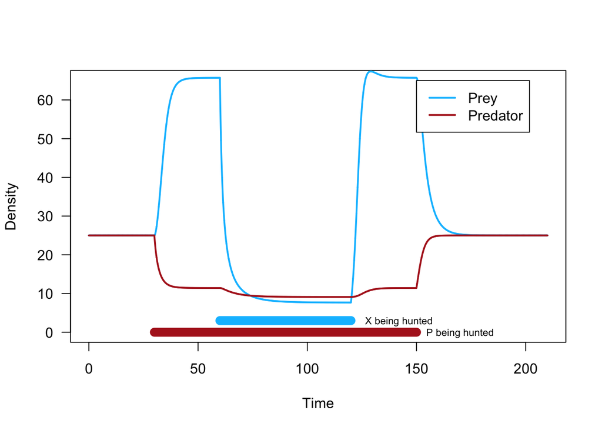

```r
# plotting unharvested system (time 0 to 100)
## plot prey
plot(x = tset, y = X.simu2,
     type = 'l', las = 1, lwd = 2, col = Xcol,
     xlab = 'Time', ylab = 'Density',
     xlim = c(0, 210), ylim = c(0, 65))
## plot predator
lines(x = tset, y = P.simu2,
      lwd = 2, col = Pcol)

# plotting harvested system (time 100 to 210)
## plot prey
lines(x = tset2, y = X.simu6,
      lwd = 2, col = Xcol)
## plot predator
lines(x = tset2, y = P.simu6,
      lwd = 2, col = Pcol)

# add a legend
legend(x = 150, y = 65,
       legend = c('Prey','Predator'),
       lwd = 2,
       col = c(Xcol, Pcol))

# add horizontal line to indicate when prey hunting occurred
lines(x = c(t_Xstart, t_stophunt), y = c(3, 3),
      lwd = 10, col = Xcol)
text(x = 142, y = 2.8, 'X being hunted', cex = .7)

# add horizontal line to indicate where predator hunting occurred
lines(x = c(t_Pstart, t_stopP), y = c(0, 0),
      lwd = 10, col = Pcol)
text(x = 170, y = -.2, 'P being hunted', cex = .7)
```

/1 axes  
/1 legend  
/1 graphical indication of predator harvest  
/1 graphical indication of prey harvest  
/2 one point per simulation line (exploitation phase)  
/2 one point per simulation line (recovery phase)  
= /8 points total

## Question 2: Effects of changing alternate prey availability

To interpret the effects of changing alternate prey availability –

1. Paste your bifurcation diagrams from part 5c here. (You should have two – one for $X^*$, and one for $P^*$, both with respect to Y.)

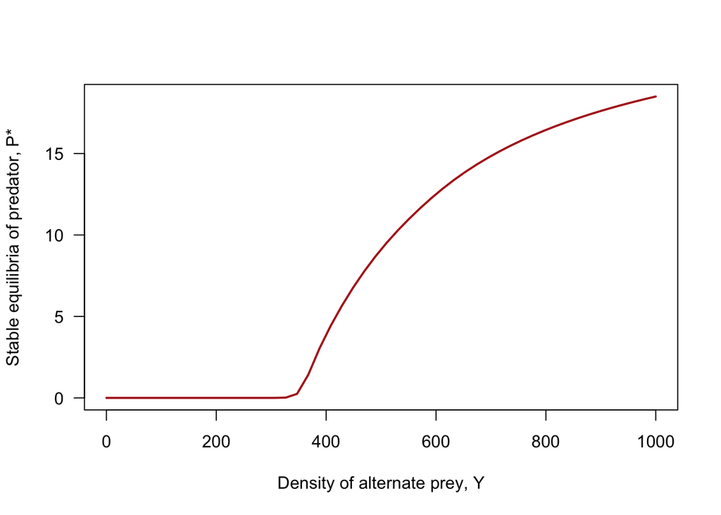

```r
Yset <- seq(from = 0, to = 1000,length.out = 50)

Xstarset <- NaN*Yset
Pstarset <- NaN*Yset

for(j in 1:length(Yset)){
    Y <- Yset[j]
    X.simu <- NaN*tset
    X.simu[1] <- 1
    P.simu <- NaN*tset
    P.simu[1] <- 1

    for(i in 2:length(tset)){
        dt <- tset[i]-tset[i-1]
        X <- X.simu[i-1]
        P <- P.simu[i-1]
        dX <- ( r_x*X*(1-X/K_x) - a_x*P*X - h_x*X ) * dt
        dP <- ( P*(c*(a_x*X+a_y*Y)-d_p)*(1-P/K_p) - h_p*P ) * dt
        X.simu[i] <- X.simu[i-1] + dX
        P.simu[i] <- P.simu[i-1] + dP
    }

    Xstarset[j] <- X.simu[length(tset)]
    Pstarset[j] <- P.simu[length(tset)]

}

# plot stable equilibria of predator (Pstarset) against density of alternate prey (Yset)
plot(x = Yset, y = Pstarset,
     type = 'l', lwd = 2, col = Pcol, las = 1,
     xlab = 'Density of alternate prey, Y', ylab = 'Stable equilibria of predator, P*')
```

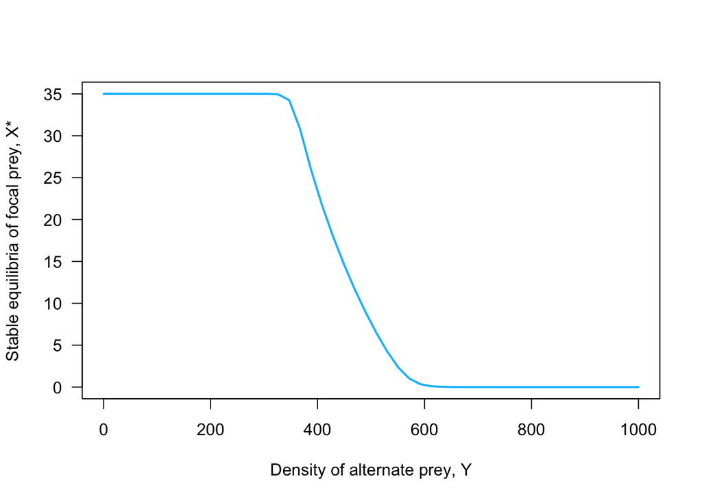

```r
# plot stable equilibria of prey (Xstarset) against density of alternate prey (Yset)
plot(x = Yset, y = Xstarset,
     type = 'l', lwd = 2, col = Xcol, las = 1,
     xlab = 'Density of alternate prey, Y', ylab = 'Stable equilibria of focal prey, X*')
```

/2 axes for two plots  
/2 X* or P* lines in two plots  
= /4 points total

2. Describe in biological terms what is happening as the alternate prey increases in density.

As density of alternate prey increases, a higher predator population can be supported. This is because a more prey means more resources to support the predator population. As the density of prey Y increases beyond a threshold (~350) the stable equilibria of prey X decreases. This could be because the predator population is growing due to an increase in Y, but it feeds indiscriminately on Y and X.

= /2 points total

3. Look up the term “apparent competition.” How does your bifurcation diagram of $X^*$ with respect to Y show this phenomenon?

Apparent competition refers to the indirect negative-negative interaction between two prey species that do not compete for resources, but are prey to the same predator species. This makes sense because the increase in Y leads to an increase in Predators, which then require more prey and feed on prey X as well as the surplus as Y.

= /2 points total

## Question 3: Choose your own bifurcation adventure

1. Choose a parameter other than Y, and make two bifurcation diagrams with this parameter on the x-axis. One bifurcation diagram should show the stable prey equilibrium ($X*$), and the other should show the stable predator equilibrium ($P*$).

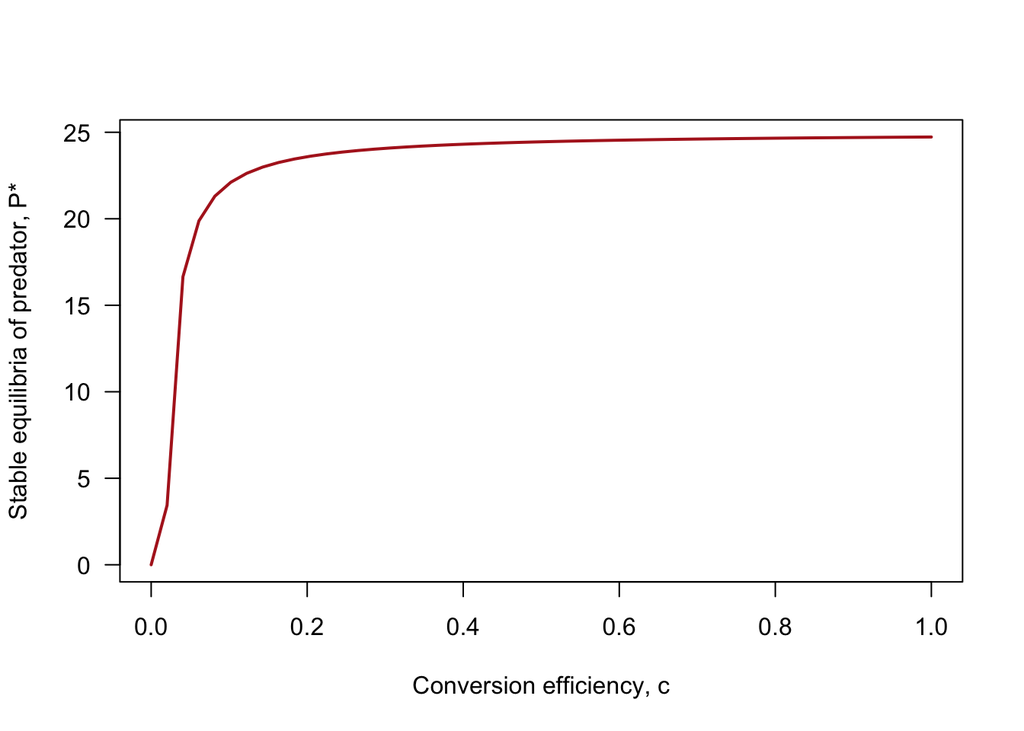

```r
cset <- seq(from = 0, to = 1,length.out = 50)

Xstarset <- NaN*cset
Pstarset <- NaN*cset

for(j in 1:length(cset)){
    c <- cset[j]
    X.simu <- NaN*tset
    X.simu[1] <- 1
    P.simu <- NaN*tset
    P.simu[1] <- 1

    for(i in 2:length(tset)){
        dt <- tset[i]-tset[i-1]
        X <- X.simu[i-1]
        P <- P.simu[i-1]
        dX <- ( r_x*X*(1-X/K_x) - a_x*P*X - h_x*X ) * dt
        dP <- ( P*(c*(a_x*X+a_y*Y)-d_p)*(1-P/K_p) - h_p*P ) * dt
        X.simu[i] <- X.simu[i-1] + dX
        P.simu[i] <- P.simu[i-1] + dP
    }

    Xstarset[j] <- X.simu[length(tset)]
    Pstarset[j] <- P.simu[length(tset)]

}

# plot stable equilibria of predator (Pstarset) against density of alternate prey (Yset)
plot(x = cset, y = Pstarset,
     type = 'l', lwd = 2, col = Pcol, las = 1,
     xlab = 'Conversion efficiency, c', ylab = 'Stable equilibria of predator, P*')
```

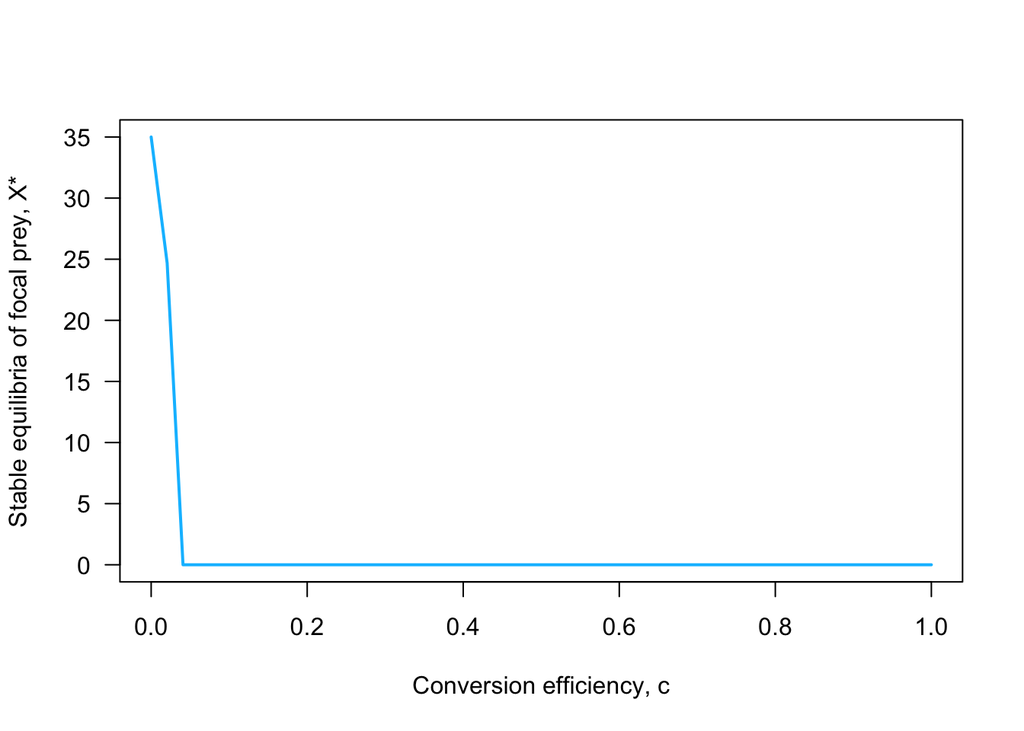

```r
# plot stable equilibria of prey (Xstarset) against density of alternate prey (Yset)
plot(x = cset, y = Xstarset,
     type = 'l', lwd = 2, col = Xcol, las = 1,
     xlab = 'Conversion efficiency, c', ylab = 'Stable equilibria of focal prey, X*')
```

/2 axes for two plots  
/2 X* or P* lines in two plots  
= /4 points total

2. Describe in biological terms what is happening. Do your results make intuitive sense?

As the predator get more efficient at converting prey biomass to predator biomass, the stable equilibria of the predator population asymptotically increases. The equilibria never surpasses 25 regardless of how good the predator is at converting prey biomass because 25 is the carrying capacity, so the predator is limited by other factors such as space or competition. The stable equilibria of the prey decreases as the conversion efficiency of the predator increases. This is because the predator population is able to convert energy into new biomass more quickly, thus creating more predators to hunt the prey.

= /2 points total

## Question 4: Impacts of reduced alternate prey on recovery scenarios

1. Set `Y` = 200. Using the same harvest rates we have chosen above (`h_x` = 0.65 and `h_p` = 0.325), find the equilibrium population sizes when harvest is occurring (i.e., in a “disassembled” or “exploited” system).

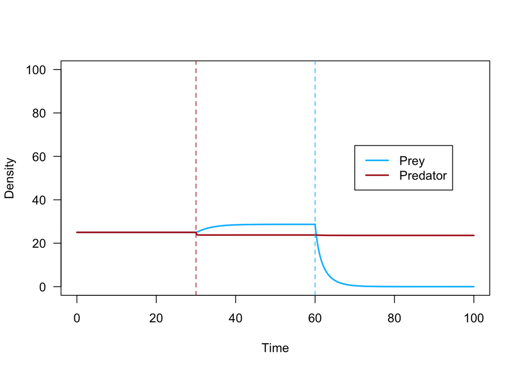

```r
Y1<-200

X0 <- 1
P0 <- 1

# generate X.simu1 to find initial starting values
tset <- seq(from = 0, to = 100, length.out = 20000)
X.simu7 <- NaN*tset
X.simu7[1] <- X0
P.simu7 <- NaN*tset
P.simu7[1] <- P0

for(i in 2:length(tset)){
    dt <- tset[i]-tset[i-1]
    X <- X.simu7[i-1]
    P <- P.simu7[i-1]
    dX <- ( r_x*X*(1-X/K_x) - a_x*P*X ) * dt
    dP <- ( P*(c*(a_x*X+a_y*Y1)-d_p)*(1-P/K_p) ) * dt
    X.simu7[i] <- X.simu7[i-1] + dX
    P.simu7[i] <- P.simu7[i-1] + dP
}


#set up intial pop sizes at eq
X0 <- X.simu7[length(tset)]
P0 <- P.simu7[length(tset)]

h_x <- 0.65
h_p <- 0.325


t_Pstart <- 30
t_Xstart <- 60

#generate X.simu8
tset <- seq(from = 0, to = 100, length.out = 20000)
X.simu8 <- NaN*tset
X.simu8[1] <- X0
P.simu8 <- NaN*tset
P.simu8[1] <- P0

for(i in 2:length(tset)){
    if(tset[i] < t_Pstart){ h_p_now <- 0 } else { h_p_now <- h_p }
    if(tset[i] < t_Xstart){ h_x_now <- 0 } else { h_x_now <- h_x }
    dt <- tset[i]-tset[i-1]
    X <- X.simu8[i-1]
    P <- P.simu8[i-1]
    dX <- ( r_x*X*(1-X/K_x) - a_x*P*X - h_x_now*X ) * dt
    dP <- ( P*(c*(a_x*X+a_y*Y1)-d_p)*(1-P/K_p) - h_p_now*P ) * dt
    X.simu8[i] <- X.simu8[i-1] + dX
    P.simu8[i] <- P.simu8[i-1] + dP
}
X1 <- X.simu8[length(tset)]
P1 <- P.simu8[length(tset)]


# plot prey (X.simu8) against time (tset)
plot(x = tset, y = X.simu8,
     type = 'l', las = 1, lwd = 2, col = Xcol,
     xlab = 'Time', ylab = 'Density',
     ylim = c(0, 100))

# plot predator (P.simu8) against time (tset)
lines(x = tset, y = P.simu8,
      lwd = 2, col = Pcol)

# add a legend
legend(x = 70, y = 65,
       lwd = 2,
       legend = c('Prey','Predator'),
       col = c(Xcol, Pcol))

# add vertical lines to indicate where hunting was turned on for each species
abline(v = t_Pstart, lty = 2, col = Pcol)
abline(v = t_Xstart, lty = 2, col = Xcol)
```

```r
print(X1)
```

```
## [1] 9.52596e-06
```

```r
print(P1)
```

```
## [1] 23.58696
```

/1 equilibrium value for prey  
/1 equilibrium value for predator  
/2 code and graph that show work by simulation  
= /4 points total

2. Simulate the three recovery scenarios (synchronous, predator-first, and prey-first). Create three timeseries graphs showing your results. Be sure to label your axes, include a legend, and indicate the time at which harvest stopped. HINT: You may need to run your timeseries for longer! Try `tset3 <- seq(100,500,length.out=22000)`

```r
# storing initial conditions of disassembled state
X1_dis <- X.simu8[length(tset)]
P1_dis <- P.simu8[length(tset)]


tset3 <- seq(100,500,length.out=22000)

## c. Scenario 1: Synchronous recovery

X.simu9 <- NaN*tset3
X.simu9[1] <- X1_dis
P.simu9 <- NaN*tset3
P.simu9[1] <- P1_dis


for(i in 2:length(tset3)){
    if(tset3[i] < t_stophunt){ h_p_now <- h_p } else { h_p_now <- 0 }

    if(tset3[i] < t_stophunt){ h_x_now <- h_x } else { h_x_now <- 0 }

    dt <- tset3[i]-tset3[i-1]
    X <- X.simu9[i-1]
    P <- P.simu9[i-1]
    dX <- (r_x*X*(1-X/K_x) - a_x*P*X - h_x_now*X ) * dt
    dP <- (P*(c*(a_x*X+a_y*Y)-d_p)*(1-P/K_p) - h_p_now*P ) * dt
    X.simu9[i] <- X.simu9[i-1] + dX
    P.simu9[i] <- P.simu9[i-1] + dP
}

head(P.simu9)
```

```
## [1] 23.58696 24.16873 24.46062 24.60155 24.66827 24.69956
```

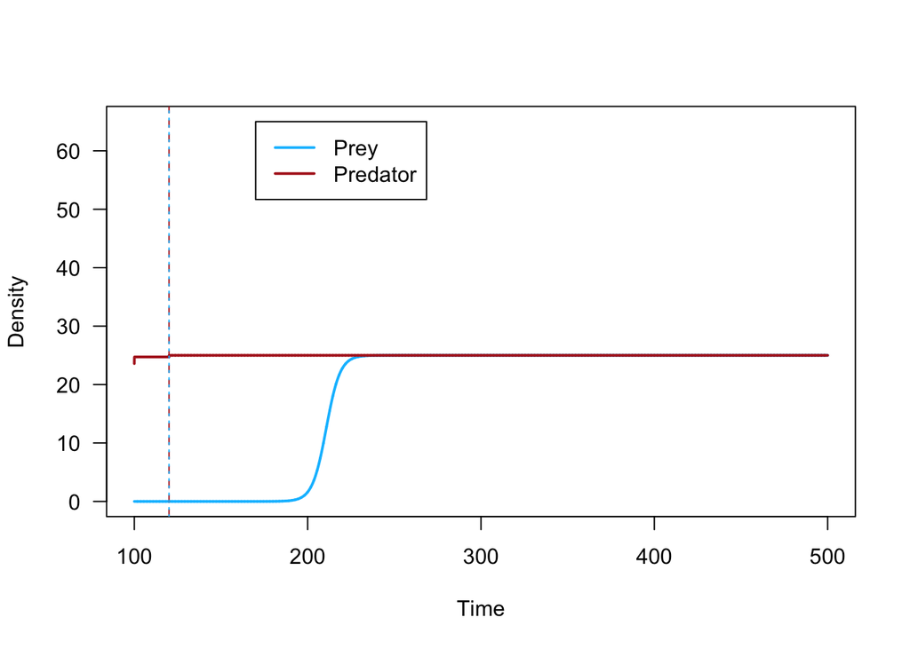

```r
plot(x = tset3, y = X.simu9,
     type = 'l', las = 1, lwd = 2, col = Xcol,
     xlab = 'Time', ylab = 'Density',
     ylim = c(0, 65))

lines(x = tset3, y = P.simu9,
      lwd = 2, col = Pcol)

legend(x = 170, y = 65,
       lwd = 2,
       legend = c('Prey', 'Predator'),
       col = c(Xcol, Pcol))

abline(v = t_stophunt, lty = 2, col = Pcol)
abline(v = t_stophunt, lty = 3, col = Xcol)
```

```r
## d. Scenario 2: Predator first recovery

X.simu10 <- NaN*tset3
X.simu10[1] <- X1_dis
P.simu10 <- NaN*tset3
P.simu10[1] <- P1_dis


for(i in 2:length(tset3)){
    if(tset3[i] < t_stophunt){ h_p_now <- h_p } else { h_p_now <- 0 }

    if(tset3[i] < t_stopX){ h_x_now <- h_x } else { h_x_now <- 0 }

    dt <- tset3[i]-tset3[i-1]
    X <- X.simu10[i-1]
    P <- P.simu10[i-1]
    dX <- (r_x*X*(1-X/K_x) - a_x*P*X - h_x_now*X ) * dt
    dP <- (P*(c*(a_x*X+a_y*Y)-d_p)*(1-P/K_p) - h_p_now*P ) * dt
    X.simu10[i] <- X.simu10[i-1] + dX
    P.simu10[i] <- P.simu10[i-1] + dP
}

head(P.simu10)
```

```
## [1] 23.58696 24.16873 24.46062 24.60155 24.66827 24.69956
```

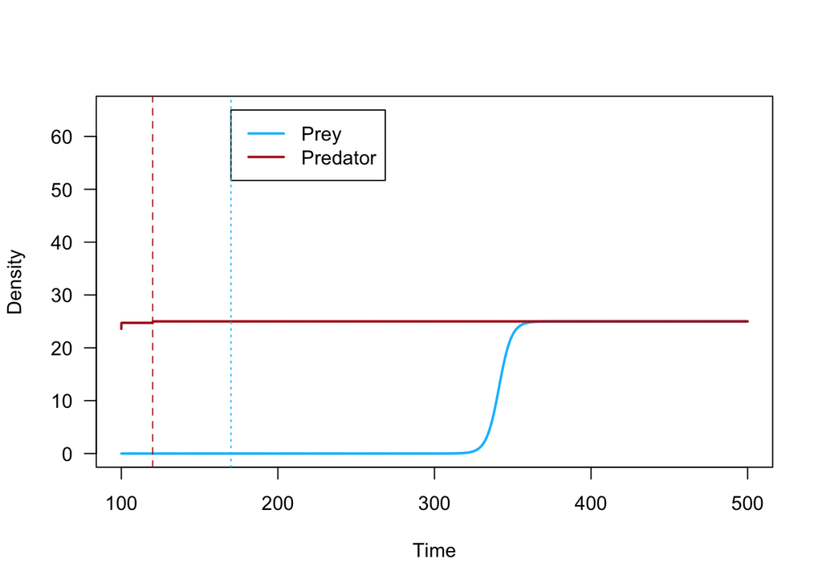

```r
plot(x = tset3, y = X.simu10,
     type = 'l', las = 1, lwd = 2, col = Xcol,
     xlab = 'Time', ylab = 'Density',
     ylim = c(0, 65))

lines(x = tset3, y = P.simu10,
      lwd = 2, col = Pcol)

legend(x = 170, y = 65,
       lwd = 2,
       legend = c('Prey', 'Predator'),
       col = c(Xcol, Pcol))

abline(v = t_stophunt, lty = 2, col = Pcol)
abline(v = t_stopX, lty = 3, col = Xcol)
```

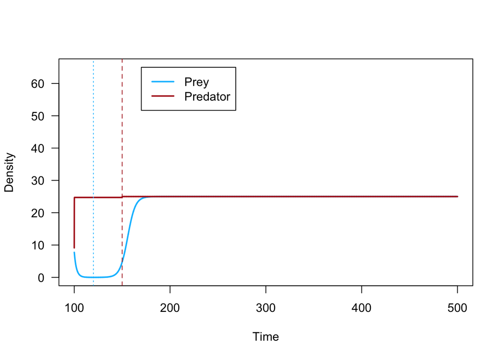

```r
## d. Scenario 3: Prey first recovery

X.simu11 <- NaN*tset3
X.simu11[1] <- X0_dis
P.simu11 <- NaN*tset3
P.simu11[1] <- P0_dis

for(i in 2:length(tset3)){

  # if time is before t_stophunt, h_p_now = h_p
  # else, h_p_now = 0
    if(tset3[i] < t_stopP){ h_p_now <- h_p } else { h_p_now <- 0 }

  # if time is before t_stopX, h_x_now = h_x
  # else, h_x_now = 0
    if(tset3[i] < t_stophunt){ h_x_now <- h_x } else { h_x_now <- 0 }

  # calculating change in time
    dt <- tset3[i]-tset3[i-1]

    # storing temporary variables
    X <- X.simu11[i-1]
    P <- P.simu11[i-1]

    # calculating change in population size
    dX <- ( r_x*X*(1-X/K_x) - a_x*P*X - h_x_now*X ) * dt
    dP <- ( P*(c*(a_x*X+a_y*Y)-d_p)*(1-P/K_p) - h_p_now*P ) * dt

    # calculating total population size and storing in holding vector
    X.simu11[i] <- X.simu11[i-1] + dX
    P.simu11[i] <- P.simu11[i-1] + dP
}

# plot prey (X.simu3) against time (tset3)
plot(x = tset3, y = X.simu11,
     type = 'l', las = 1, lwd = 2, col = Xcol,
     xlab = 'Time', ylab = 'Density',
     ylim = c(0, 65))

# plot predator (P.simu3) against time (tset3)
lines(x = tset3, y = P.simu11,
      lwd = 2, col = Pcol)

# add a legend
legend(x = 170, y = 65,
       lwd = 2,
       legend = c('Prey', 'Predator'),
       col = c(Xcol, Pcol))

# add vertical lines to indicate where hunting stopped
abline(v = t_stopP, lty = 2, col = Pcol)
abline(v = t_stophunt, lty = 3, col = Xcol)
```

/3 axes for three plots  
/6 predator and prey lines for three plots  
/6 graphical indication of when hunting stops  
/3 legends for three plots  
= /18 points total

3. Compare your findings to one another. For which scenario was overall recovery to an unexploited state fastest?

= /2 points total

4. Compare your findings to those of Samhouri et al. (2017). What do your results suggest about the importance of a secondary prey type to predator-first recovery?

It is extremely important. without a secondary prey, it takes prey x a long time to return to an equilibrium state under a regime of already recovered predators. This is because, despite the release in hunting pressure(h_x), they are still under a high predation pressure (a_x).

= /2 points total

= /48 points total